# Centrality Zoo coverage matrix

Source: average Kendall rank correlation between node rankings of 349 measures over 648 ICON networks ([Centrality Zoo](https://centralityzoo.github.io/comparison/), Shvydun 2025). `cograph` implements 101 distinct measures covering 102 of those labels, 38 of them added in batches 7 to 9. Colour: white = 0, blue = 1 for correlations; red to blue through white for differences. Every figure is followed by the numbers, so nothing is encoded by colour alone.

## Covered measures: the Zoo’s view

Rows and columns are labelled with the cograph name and ordered by hierarchical clustering of `1 - tau`, so redundant measures sit together.

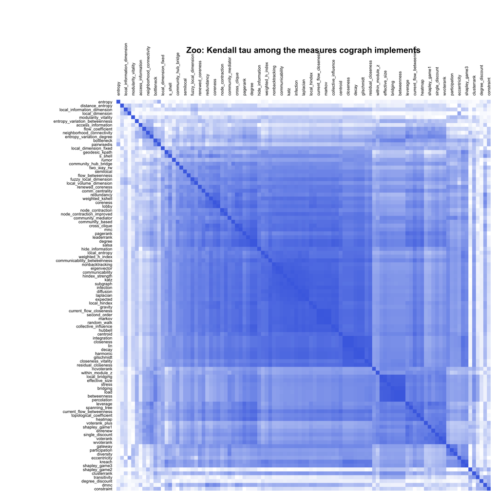

### Redundant pairs inside cograph (tau >= 0.95)

| measure_1 | measure_2 | tau |
| --- | --- | --- |
| betweenness | percolation | 1.00 |
| closeness | lin | 1.00 |
| current_flow_closeness | second_order | 1.00 |
| degree | salsa | 1.00 |
| harmonic | gilschmidt | 1.00 |
| integration | closeness | 1.00 |
| integration | lin | 1.00 |
| load | betweenness | 1.00 |
| load | percolation | 1.00 |
| current_flow_closeness | markov | 0.99 |
| markov | random_walk | 0.99 |
| second_order | markov | 0.99 |
| bridging | load | 0.98 |
| bridging | betweenness | 0.98 |
| bridging | percolation | 0.98 |
| current_flow_closeness | random_walk | 0.98 |
| decay | harmonic | 0.98 |
| decay | gilschmidt | 0.98 |
| laplacian | expected | 0.98 |
| second_order | random_walk | 0.98 |
| collective_influence | hubbell | 0.97 |
| diffusion | laplacian | 0.97 |
| diffusion | expected | 0.97 |
| eigenvector | communicability | 0.97 |
| katz | subgraph | 0.97 |
| local_bridging | effective_size | 0.97 |
| closeness | decay | 0.96 |
| communicability | subgraph | 0.96 |
| infection | laplacian | 0.96 |
| integration | decay | 0.96 |
| lin | decay | 0.96 |
| nonbacktracking | eigenvector | 0.96 |
| hindex_strength | infection | 0.95 |
| infection | diffusion | 0.95 |
| katz | infection | 0.95 |
| subgraph | infection | 0.95 |

## Our measurements against the Zoo

The same 97 measures computed on 19 real undirected networks (10 to 81 nodes: karate, kite, UKfaculty, macaque, 12 food webs, les_miserables, florentine, davis), pairwise Kendall tau averaged over networks, then compared pair by pair.

| Statistic over the 4654 measure pairs | Value |
| --- | --- |
| Correlation between the two matrices | 0.69 |
| Mean absolute difference | 0.14 |
| Median absolute difference | 0.09 |
| Pairs agreeing within 0.20 | 78% |

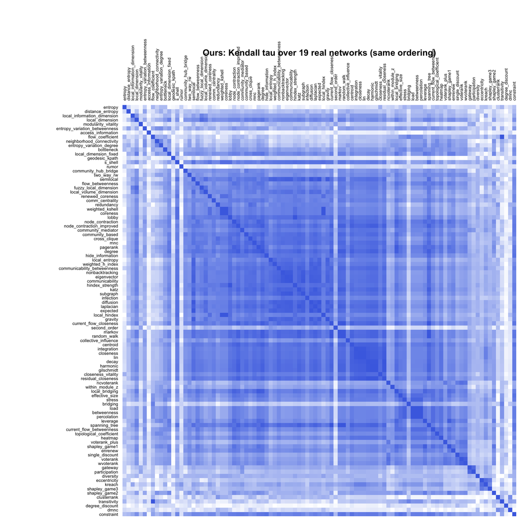

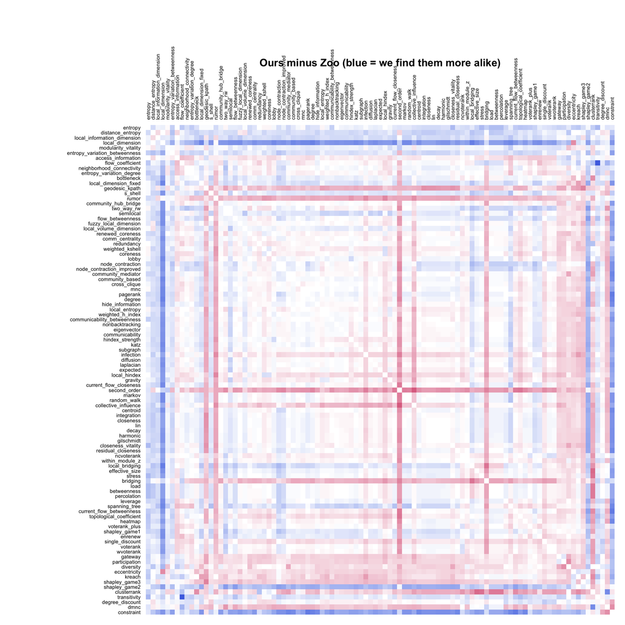

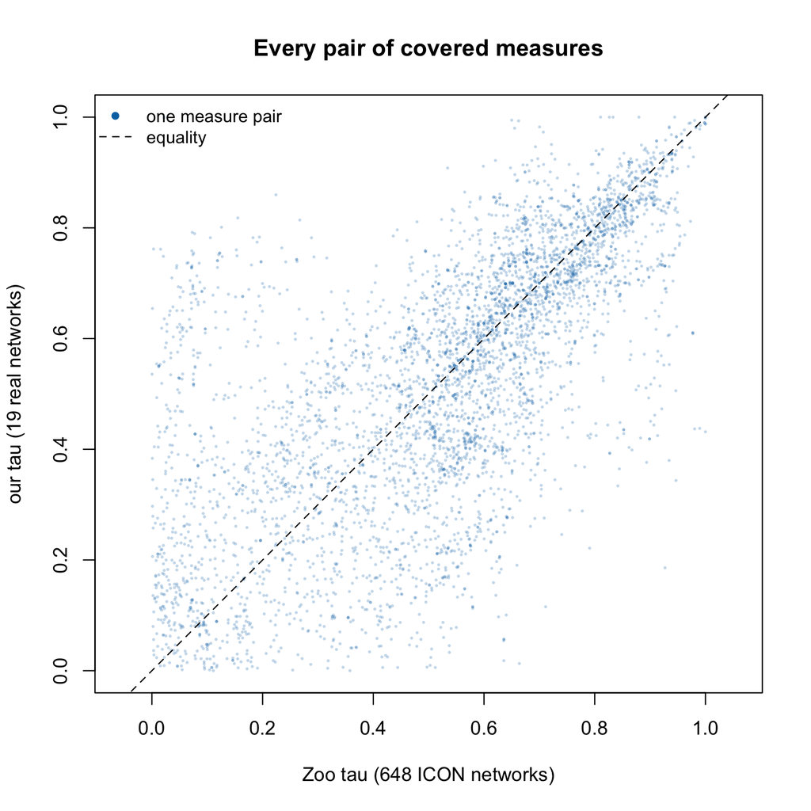

### Where the two disagree most

An earlier run of this report put `katz` among the worst rows. That turned out to be cograph’s own defect rather than a convention difference: Katz converges only for an attenuation below one over the spectral radius, and the 0.1 default is invalid on several of these food webs. This run uses a valid attenuation per network, and `katz` moved from a profile correlation of 0.56 to 0.76. `centrality()` now warns when the attenuation cannot converge.

| measure_1 | measure_2 | zoo | ours | difference |
| --- | --- | --- | --- | --- |
| flow_coefficient | transitivity | 0.02 | 1.00 | 0.98 |
| pagerank | constraint | 0.00 | 0.76 | 0.76 |
| current_flow_betweenness | constraint | 0.02 | 0.76 | 0.75 |
| second_order | collective_influence | 0.93 | 0.19 | -0.74 |
| local_dimension | local_bridging | 0.02 | 0.75 | 0.73 |
| local_dimension | degree | 0.07 | 0.79 | 0.72 |
| degree | constraint | 0.08 | 0.79 | 0.71 |
| local_dimension | local_dimension_fixed | 0.04 | 0.73 | 0.69 |
| community_mediator | constraint | 0.07 | 0.76 | 0.69 |
| local_dimension | mnc | 0.08 | 0.75 | 0.68 |
| local_dimension | spanning_tree | 0.04 | 0.73 | 0.68 |
| centroid | constraint | 0.13 | 0.80 | 0.68 |
| residual_closeness | constraint | 0.07 | 0.75 | 0.68 |
| spanning_tree | constraint | 0.11 | 0.78 | 0.68 |
| local_dimension | community_based | 0.06 | 0.74 | 0.67 |
| local_dimension | pagerank | 0.07 | 0.74 | 0.67 |
| heatmap | constraint | 0.04 | 0.71 | 0.67 |
| local_dimension | katz | 0.07 | 0.73 | 0.66 |
| local_dimension | current_flow_closeness | 0.07 | 0.73 | 0.66 |
| local_dimension | markov | 0.07 | 0.73 | 0.66 |
| local_dimension | random_walk | 0.07 | 0.73 | 0.66 |
| hide_information | constraint | 0.16 | 0.82 | 0.66 |
| local_dimension | lobby | 0.05 | 0.69 | 0.65 |
| effective_size | clusterrank | 0.66 | 0.01 | -0.65 |
| clusterrank | dmnc | 0.00 | 0.65 | 0.65 |

## Per-measure agreement with the Zoo

Each measure’s row of tau values, correlated with the Zoo’s row for the same measure. Established measures set the achievable band, since the two matrices come from different network collections.

[output not shown]

[output cut: 67 more lines]

## Uncovered measures with real new information

The 27 Zoo measures whose maximum tau against any cograph measure is below 0.70, against all covered measures.

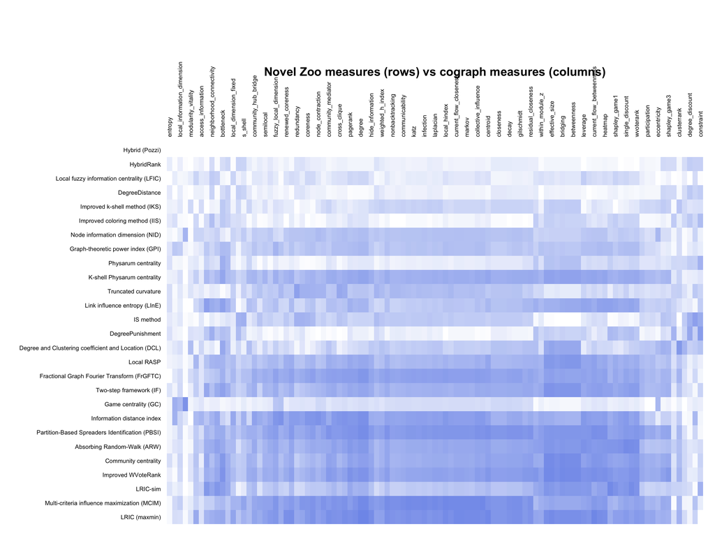

| zoo_measure | max_tau | nearest_cograph |
| --- | --- | --- |
| Hybrid (Pozzi) | 0.00 | degree |
| HybridRank | 0.27 | degree_discount |
| Local fuzzy information centrality (LFIC) | 0.28 | neighborhood_connectivity |
| DegreeDistance | 0.30 | degree_discount |
| Improved k-shell method (IKS) | 0.32 | clusterrank |
| Improved coloring method (IIS) | 0.37 | constraint |
| Graph-theoretic power index (GPI) | 0.41 | fuzzy_local_dimension |
| Node information dimension (NID) | 0.41 | local_dimension |
| Physarum centrality | 0.44 | bottleneck |
| K-shell Physarum centrality | 0.52 | local_bridging |
| Truncated curvature | 0.52 | redundancy |
| Link influence entropy (LInE) | 0.53 | flow_coefficient |
| IS method | 0.54 | dmnc |
| DegreePunishment | 0.55 | constraint |
| Local RASP | 0.58 | load |
| Degree and Clustering coefficient and Location (DCL) | 0.58 | clusterrank |
| Fractional Graph Fourier Transform (FrGFTC) | 0.59 | degree |
| Two-step framework (IF) | 0.60 | effective_size |
| Game centrality (GC) | 0.61 | local_dimension |
| Information distance index | 0.63 | degree |
| Partition-Based Spreaders Identification (PBSI) | 0.64 | degree |
| Absorbing Random-Walk (ARW) | 0.65 | single_discount |
| Community centrality | 0.66 | effective_size |
| Improved WVoteRank | 0.66 | bridging |
| LRIC-sim | 0.67 | voterank_plus |
| Multi-criteria influence maximization (MCIM) | 0.68 | hubbell |
| LRIC (maxmin) | 0.70 | degree |

## Full coverage document

What the [Centrality Zoo comparison](https://centralityzoo.github.io/comparison/) (Shvydun 2025, *Zoo of Centralities*, arXiv:2511.05122) says about cograph’s `centrality()` surface. Generated by `docs/zoo/zoo_coverage.py` from the site’s `correlation.json` (gzipped copy in `docs/zoo/`). Regenerate after adding measures; edit the `COVERED` map in the script, not this file.

## Source

- Matrix of average **Kendall rank correlation** between node rankings, 349 measures, computed on 648 empirical networks from the Index of Complex Networks (ICON). The encyclopedia assumes undirected, unweighted, loop-free graphs, so redundancy on a directed weighted transition matrix may differ.
- Off-diagonal tau: min 0.00, median 0.67, mean 0.63, max 1.00.
- The Zoo’s own code is unreleased (its Code page says so), so nothing here is validated against Zoo output. cograph validates each measure against reference packages, published worked examples, or brute-force igraph.

## Summary

| Group | Count |
| --- | --- |
| Zoo measures covered by cograph | 102 |
| Zoo measures not in cograph | 247 |
| … of which rank-identical to a cograph measure (tau >= 0.99) | 18 |
| … near-duplicate (0.90 <= tau < 0.99) | 158 |
| … some new signal (0.70 <= tau < 0.90) | 44 |
| … real new information (tau < 0.70) | 27 |
| cograph measures with no Zoo counterpart | 24 |

`tau` below is the **maximum** Kendall correlation between the Zoo measure and any measure cograph already computes; `nearest` names that cograph twin (Zoo label). A tau of 0.99 or more means the two rank nodes identically on essentially every one of the 648 networks, so adding the measure buys nothing.

## Covered: Zoo label to cograph measure

| Zoo label | cograph measure |
| --- | --- |
| Degree | `degree` |
| Eigenvector | `eigenvector` |
| Katz | `katz (also alpha)` |
| PageRank | `pagerank` |
| Betweenness | `betweenness` |
| Flow betweenness | `flow_betweenness` |
| Current-flow betweenness | `current_flow_betweenness` |
| Closeness | `closeness` |
| Harmonic | `harmonic` |
| Decay | `decay` |
| Subgraph | `subgraph` |
| Laplacian | `laplacian` |
| Percolation | `percolation` |
| k-shell | `coreness` |
| CollInf | `collective_influence` |
| Current-flow Closeness | `current_flow_closeness (also information)` |
| BottleNeck | `bottleneck` |
| Centroid | `centroid` |
| Closeness vitality | `closeness_vitality` |
| ClusterRank | `clusterrank` |
| Communicability betweenness | `communicability_betweenness` |
| Cross-Clique Connectivity | `cross_clique` |
| Diffusion Degree | `diffusion` |
| MNC | `mnc` |
| DMNC | `dmnc` |
| Load | `load` |
| m-reach | `kreach` |
| Geodesic k-path | `geodesic_kpath [batch 9]` |
| Second order centrality | `second_order` |
| VoteRank | `voterank` |

[output cut: 72 more lines]

## Rank-identical to an existing measure (tau >= 0.99): not needed

| Zoo measure | tau | nearest cograph twin |
| --- | --- | --- |
| AIC | 1.00 | Lin’s index (`lin`) |
| Cumulative contact probability (CCP) | 1.00 | SALSA (`salsa`) |
| Degree mass | 1.00 | Diffusion Degree (`diffusion`) |
| Electrical closeness | 1.00 | Current-flow Closeness (`current_flow_closeness (also information)`) |
| Linearly scaled betweenness | 1.00 | Percolation (`percolation`) |
| Nieminen’s closeness | 1.00 | Lin’s index (`lin`) |
| QJSD centrality | 1.00 | SALSA (`salsa`) |
| Routing betweenness | 1.00 | Load (`load`) |
| Total Effects Centrality (TEC) | 1.00 | SALSA (`salsa`) |
| Zeta vector centrality | 1.00 | Second order centrality (`second_order`) |
| Dynamical Influence | 1.00 | Eigenvector (`eigenvector`) |
| ViralRank | 1.00 | Current-flow Closeness (`current_flow_closeness (also information)`) |
| epsilon-betweenness | 1.00 | Percolation (`percolation`) |
| DirichletRank | 1.00 | SALSA (`salsa`) |
| Immediate Effects Centrality (IEC) | 1.00 | Markov (`markov`) |
| Improved neighbors’ k-core (INK) | 1.00 | Local H-index (`local_hindex`) |
| Length-scaled betweenness | 0.99 | Percolation (`percolation`) |
| Hybrid degree centrality | 0.99 | Hubbel (`hubbell`) |

## Near-duplicates (0.90 <= tau < 0.99): low value

Grouped by the cograph twin they collapse onto. Most are re-weightings of degree, coreness and hop distance (the gravity, k-shell-hybrid, TOPSIS and entropy-mix families).

| cograph twin (Zoo label) | n | Zoo measures |
| --- | --- | --- |
| SALSA (`salsa`) | 23 | Mixed Degree Decomposition (MDD); Mixed core, degree and entropy (MCDE); Mixed core, degree and weighted entropy (MCDWE); VMM algorithm; Classified neighbors centrality; Counting Betweenness; Coleman-… |
| Diffusion Degree (`diffusion`) | 17 | k-path; Clustering degree algorithm (CDA); Weight degree centrality (Wdc); Laplacian gravity centrality (LGC); Improved global structure model (IGSM); Mixed core, semi-local degree and entropy (MCSDE)… |
| Infection number (`infection`) | 16 | Dynamics-sensitive (DS) centrality; Extended improved k-shell hybrid (EIKH); Extended k-shell hybrid method; Diffusion centrality; SpectralRank; Bridging capital; Weighted gravity model (WGravity); Mu… |
| Hubbel (`hubbell`) | 15 | Expected force (ExFm); Mapping entropy (ME); Gravity model; Local gravity model; Graph regularization centrality (GRC); Weighted k-shell degree neighborhood (Maji); Shell clustering coefficient; Weigh… |
| Laplacian (`laplacian`) | 7 | Neighbor distance centrality; LineRank; Global and Local Structure(GLS); k-shell hybrid method; Global importance of nodes (GIN); Random walk-based gravity (DFS-Gravity); Hybrid Global Structure Model… |
| Total communicability (`communicability`) | 7 | Node and Neighbor Layer Information (NINL) centrality; Extended Cluster Coefficient Ranking Measure (ECRM); Extended neighborhood coreness; Extended weight degree centrality (EWdc); Extended RMD-weigh… |
| Communicability betweenness (`communicability_betweenness`) | 6 | Mediative Effects Centrality (MEC); Multi-evidence centrality (MeC); Entropy-based gravity model; NWRank; TOPSIS; Inward accessibility |
| Leverage (`leverage`) | 6 | PhysarumSpreader; BG-index; Bridging coefficient; INF centrality; beta-measure; Malatya centrality |
| Gravity centrality (`gravity`) | 5 | Weighted k-shell degree neighborhood (Wksd); Mixed gravitational centrality; Neighborhood centrality; Global Structure Model (GSM); KDEC method |
| h-index strength (`hindex_strength`) | 5 | Extended H-index centrality (EHC); Influence capability (IC); Entropy-Based Ranking Measure (ERM); Extended diversity-strength ranking (EDSR); Extended mixed gravitational centrality |
| Bridging centrality (`bridging`) | 4 | Relative entropy; Proximal betwenness; Extended LBC; Mapping Entropy Betweenness (MEB) |
| Markov (`markov`) | 4 | Local structural centrality (LSC); Normalized local centrality (NLC); Edge-disjoint k-path; Path-transfer centrality |
| Residual closeness (`residual_closeness`) | 4 | Distance-weighted fragmentation; Efficiency centrality (EffC); Total centrality; Exogenous centrality |
| Harmonic (`harmonic`) | 3 | Weighted TOPSIS; Analytic Hierarchy Process (AHP) centrality; Hybrid centrality (HC) |
| PageRank (`pagerank`) | 3 | ArticleRank; Random walk decay; Randomized shortest paths (RSP) betweenness |
| Percolation (`percolation`) | 3 | delta-betweenness; k-betweenness; TOPSIS-RE |
| Random walk centrality (`random_walk`) | 3 | Improved iterative resource allocation (IIRA); Node importance contribution correlation matrix (NICCM) method; Vertex-disjoint k-path |
| CollInf (`collective_influence`) | 2 | KED; Improved entropy-based centrality |
| Cross-Clique Connectivity (`cross_clique`) | 2 | All cycle betweenness (ACC); Edge clustering coefficient centrality (NC) |
| Effective size (`effective_size`) | 2 | Godfather index; Egocentric betweenness |
| Eigenvector (`eigenvector`) | 2 | Dynamical importance; Hierarchical k-shell (HKS) |
| Lin’s index (`lin`) | 2 | delta-closeness; Improved closeness centrality (ICC) |
| Lobby index (`lobby`) | 2 | Improved K-shell decomposition (IKSD); μ-Power Community Index (μ-PCI) |
| Local H-index (`local_hindex`) | 2 | RMD-weighted degree (WD); Iterative resource allocation (IRA) |
| MNC (`mnc`) | 2 | Support; ProfitLeader |
| Spanning tree centrality (STC) (`spanning_tree`) | 2 | Resistance curvature; DST |
| Subgraph (`subgraph`) | 2 | Neighborhood core diversity centrality (Cncd); X-nonbacktracking centrality |
| Closeness vitality (`closeness_vitality`) | 1 | Average shortest path centrality (AC) |
| Current-flow Closeness (`current_flow_closeness (also information)`) | 1 | NL centrality |
| Current-flow betweenness (`current_flow_betweenness`) | 1 | RCFB centrality |
| Local entropy (LE) (`local_entropy [batch 9]`) | 1 | CON score |
| Second order centrality (`second_order`) | 1 | ControlRank |
| k-shell (`coreness`) | 1 | k-truss number |
| m-reach (`kreach`) | 1 | Volume centrality |

## Some new signal (0.70 <= tau < 0.90)

| Zoo measure | tau | nearest cograph twin |
| --- | --- | --- |
| Transportation centrality | 0.90 | SALSA |
| Similarity-based PageRank | 0.90 | PageRank |
| PathRank | 0.90 | Non-backtracking centrality |
| Curvature index | 0.90 | Current-flow betweenness |
| WRank | 0.90 | Eigenvector |
| Integral k-shell | 0.90 | Diffusion Degree |
| theta-centrality | 0.90 | Gravity centrality |
| Cc-Burt | 0.89 | Local H-index |
| Isolating Centrality (ISC) | 0.89 | Pairwise disconnectivity |
| Graph Fourier Transform Centrality (GFT-C) | 0.88 | SALSA |
| Weighted community betweenness | 0.88 | Bridging centrality |
| Multiple local attributes weighted centrality (LWC) | 0.88 | MNC |
| MABIE | 0.88 | Current-flow betweenness |
| Spreading strength | 0.88 | Geodesic k-path |
| Interdependence | 0.87 | SALSA |
| Entropy-based influence disseminator (EbID) | 0.87 | SALSA |
| Hierarchical reduction by betweenness | 0.87 | Effective size |
| Generalized gravity centrality (GGC) | 0.86 | Gravity centrality |
| Node local centrality (NLC) | 0.85 | Cross-Clique Connectivity |
| Local degree dimension (LDD) | 0.85 | Centroid |
| Random walk accessibility (RWA) | 0.85 | Diffusion Degree |
| Shortest cycle closeness (SCC) | 0.85 | Second order centrality |
| Contribution centrality | 0.84 | Eigenvector |
| Clustered local-degree (CLD) | 0.84 | Diffusion Degree |
| Outward accessibility | 0.84 | Local entropy (LE) |
| Effective distance gravity (EffG) | 0.83 | Diffusion Degree |
| SRIC | 0.82 | Leverage |
| Mutual information | 0.82 | Shapley value (game 1) |
| Graphlet degree centrality (GDC) | 0.82 | Second order centrality |
| Return Random Walk Gravity (RRWG) | 0.82 | CollInf |
| Relative local–global importance (RLGI) | 0.81 | Leverage |
| Node importance contribution matrix (NICM) method | 0.81 | Closeness vitality |
| Gromov centrality | 0.81 | SALSA |
| EPC | 0.80 | Random walk centrality |
| Multi-local dimension (MLD) | 0.80 | Fuzzy local dimension (FLD) |
| Neighborhood density | 0.78 | MNC |
| Weighted volume centrality | 0.78 | Geodesic k-path |
| BridgeRank | 0.76 | Lin’s index |
| Semi-local degree and clustering coefficient | 0.76 | m-reach |
| Expected rank | 0.75 | Current-flow betweenness |
| Algebraic centrality | 0.74 | Closeness vitality |
| Shapley Value based Information Delimiters (SVID) | 0.74 | SALSA |
| DSHC method | 0.73 | VoteRank++ |
| E-Burt | 0.71 | Burt’s constraint |

## Real new information (tau < 0.70)

| Zoo measure | tau | nearest cograph twin |
| --- | --- | --- |
| Hybrid (Pozzi) | 0.00 | s-shell index |
| HybridRank | 0.27 | DegreeDiscountIC |
| Local fuzzy information centrality (LFIC) | 0.28 | Neighborhood connectivity |
| DegreeDistance | 0.30 | DegreeDiscountIC |
| Improved k-shell method (IKS) | 0.32 | ClusterRank |
| Improved coloring method (IIS) | 0.37 | Burt’s constraint |
| Node information dimension (NID) | 0.41 | Local dimension (Pu) |
| Graph-theoretic power index (GPI) | 0.41 | Fuzzy local dimension (FLD) |
| Physarum centrality | 0.44 | BottleNeck |
| K-shell Physarum centrality | 0.52 | Localized bridging centrality |
| Truncated curvature | 0.52 | Redundancy |
| Link influence entropy (LInE) | 0.53 | Flow coefficient |
| IS method | 0.54 | DMNC |
| DegreePunishment | 0.55 | Burt’s constraint |
| Degree and Clustering coefficient and Location (DCL) | 0.58 | ClusterRank |
| Local RASP | 0.58 | Load |
| Fractional Graph Fourier Transform (FrGFTC) | 0.59 | SALSA |
| Two-step framework (IF) | 0.60 | Effective size |
| Game centrality (GC) | 0.61 | Local dimension (Pu) |
| Information distance index | 0.63 | SALSA |
| Partition-Based Spreaders Identification (PBSI) | 0.64 | SALSA |
| Absorbing Random-Walk (ARW) | 0.65 | SingleDiscount |
| Community centrality | 0.66 | Effective size |
| Improved WVoteRank | 0.66 | Bridging centrality |
| LRIC-sim | 0.67 | VoteRank++ |
| Multi-criteria influence maximization (MCIM) | 0.68 | Hubbel |
| LRIC (maxmin) | 0.70 | SALSA |

## Backlog

Batch 7 (2026-09-06) shipped distance entropy, local dimension, local information dimensionality, modularity vitality and neighborhood connectivity; batch 8 (same day) shipped every remaining item of the ranked list: the three Shapley games, access and hide information, rumor centrality, community hub-bridge, entropy variation (degree and betweenness), the s-shell index, DegreeDiscountIC, SingleDiscount and NCVoteRank. Batch 9 (same day) shipped twenty more: the community trio (CbC, Comm, CbM), three dimension measures, WVoteRank, EnRenew, VoteRank++, node contraction (plain and improved), two-way random-walk betweenness, heatmap, flow coefficient, local entropy, weighted h-index, redundancy, weighted k-shell, renewed coreness and geodesic k-path. Nothing is queued.

Deliberately skipped:

- **Hybrid (Pozzi)**: tau 0.00 with all 348 partners: looks like a broken run, not a measure
- **Physarum / K-shell Physarum centrality**: iterative flow solver, heavy
- **Absorbing Random-Walk (ARW)**: set-function greedy, heavy
- **LRIC family, SRIC, Interdependence**: author’s own long-range-influence measures; no closed form
- **Node information dimension (NID)**: box scheme in the encyclopedia is ambiguous; original paper paywalled
- **Game centrality (GC), Algebraic centrality, Community centrality**: definition not pinned
- **DegreePunishment**: source article (Wang, Su, Zhao & Yi 2016) unobtainable; Zoo entry alone leaves beta_c and the seed rule open
- **Improved WVoteRank**: source article (Kumar & Panda 2022) unobtainable; Zoo formula has three unresolved switches
- **Local degree dimension (LDD)**: source article (Zhong, Zhang & Deng 2022) unobtainable; the Zoo formula’s bracketing is ambiguous
- **Multi-local dimension (MLD)**: for every q outside (0, 1) it is q/(q-1) times local_dimension, reversed inside (0, 1), and q = 1 is local_information_dimension over the full range; nothing new to rank

## cograph measures with no Zoo counterpart

`strength`, `authority`, `hub`, `power`, `radiality`, `dangalchev`, `generalized_closeness`, `harary`, `average_distance`, `barycenter`, `wiener`, `lac`, `onion`, `reaching_local`, `trophic_level`, `prestige_domain`, `prestige_domain_proximity`, `brokerage_coordinator`, `brokerage_itinerant`, `brokerage_representative`, `brokerage_gatekeeper`, `brokerage_liaison`, `expected_influence_1`, `expected_influence_2`